# Algorithm Walk-Through

This notebook will walkthrough the preprocessing steps as well as the ML algorithm training procedure used for the multi-dimensional, multi-output data.

## Code

### Packages

```
import sys
sys.path.insert(0, "/media/disk/erc/papers/2019_ML_OCN/ml4ocean/src")

# Standard packages
import numpy as np
import pandas as pd

# Datasets
from data.make_dataset import DataLoader, load_standard_data, load_high_dim_data, load_labels

# Features
from features.build_features import times_2_cycles, geo_2_cartesian, get_geodataframe, CycleTransform, GeoCartTransform
from features.pca_features import transform_all, transform_individual
from features.analysis import get_stats
from sklearn.preprocessing import StandardScaler
from data.make_dataset import ValidationFloats

# ML Models
from sklearn.model_selection import train_test_split
from models.baseline import train_rf_model
import statsmodels.api as smi

# Visualization
from visualization.visualize import plot_mo_stats, plot_geolocations, get_depth_labels
from sklearn.inspection import permutation_importance
import matplotlib.pyplot as plt
plt.style.use('seaborn-poster')

%load_ext autoreload
%autoreload 2
```

[output not shown]

### 1 Load Data

#### 1.1 Core Data

In this step, we will load the standard data. This includes the following variables:

- SLA
- PAR
- RHO WN 412
- RHO WN 443
- RHO WN 490
- RHO WN 555
- RHO WN 670
- MLD
- Lat
- Lon
- DOY

```
X_core = load_standard_data('NA', training=True)

# Testing Data
X_core_te = load_standard_data('NA', training=False)


X_core_te = X_core_te.iloc[:, 2:]

X_core.shape, X_core_te.shape
```

[output not shown]

#### 1.2 High Dimensional Data

In this section, we will extract the high dimensional datasets. They include:

- Temperature
- Density
- Salinity
- Spiciness

```
X_temp, X_dens, X_sal, X_spicy = load_high_dim_data('NA', training=True)

# add prefix (Training/Validation)
X_temp = X_temp.add_prefix('temp_')
X_dens = X_dens.add_prefix('dens_')
X_sal = X_sal.add_prefix('sal_')
X_spicy = X_spicy.add_prefix('spice_')

#
X_temp_te, X_dens_te, X_sal_te, X_spicy_te = load_high_dim_data('NA', training=False)


# Subset
X_temp_te = X_temp_te.iloc[:, 2:]
X_dens_te = X_dens_te.iloc[:, 2:]
X_sal_te= X_sal_te.iloc[:, 2:]
X_spicy_te = X_spicy_te.iloc[:, 2:]

# add prefix (Test)
X_temp_te = X_temp_te.add_prefix('temp_')
X_dens_te = X_dens_te.add_prefix('dens_')
X_sal_te = X_sal_te.add_prefix('sal_')
X_spicy_te = X_spicy_te.add_prefix('spice_')
```

#### 1.3 - Multi-Output Data

We load the multioutput regression labels.

```
y = load_labels('NA', training=True)

yte = load_labels('NA', training=False)

yte = yte.iloc[:, 2:]
```

#### 1.4 - Concatentate Data

```
# Training Data
Xtr = pd.concat([
    X_core,
    X_temp,
    X_dens,
    X_sal,
    X_spicy
], axis=1)



# Testing Data
Xte = pd.concat([
    X_core_te,
    X_temp_te,
    X_dens_te,
    X_sal_te,
    X_spicy_te
], axis=1)
```

```
Xtr.shape, Xte.shape
```

```
((2860, 1115), (162, 1115))
```

1. PCA Transform High Dimensional Variables

1. Normalize Core Variables

We will use a standard scaler to make the core variables with a mean of 0 and standard deviation of 1. The ML algorithms tend to perform better with this type of standardization.

1. Coordinate Transformation

In this step, we will do a simple coordinate transformation of the lat,lon variables from geospatial to cartesian coordinates. This will increase the dimensionality of our dataset from 11 dimensions to 12 dimensions.

1. Time Transformation

In this step, we will transform the `doy` coordinates to cycles of sines and cosines. This will increase the dimensionality of our data from from 12 to 13.

```
from sklearn.compose import ColumnTransformer
from sklearn.base import BaseEstimator, TransformerMixin
from sklearn.decomposition import PCA
```

```
# new columns columns
temp_columns = X_temp.columns.values
dens_columns = X_dens.columns.values
sal_columns = X_sal.columns.values
spicy_columns = X_spicy.columns.values
core_columns = ['sla', "PAR","RHO_WN_412","RHO_WN_443","RHO_WN_490","RHO_WN_555","RHO_WN_670","MLD"]
time_columns = ['doy']
loc_columns = ['lat', 'lon']

n_components = 5
times = ['doy']

new_columns = [
    *["doy_cos", "doy_sin"],
    *['x', 'y', 'z',],
    *[f"temperature_pc{icomponent+1}" for icomponent in range(n_components)],
    *[f"density_pc{icomponent+1}" for icomponent in range(n_components)],
    *[f"salinity_pc{icomponent+1}" for icomponent in range(n_components)],
    *[f"spicy_pc{icomponent+1}" for icomponent in range(n_components)],
    *core_columns,
]
seed = 123

# define transfomer
X_transformer = ColumnTransformer(
    [   ("time", CycleTransform(times), time_columns),
        ("space", GeoCartTransform(), loc_columns),
        ('temp', PCA(n_components=n_components, random_state=seed), temp_columns),
        ('dens', PCA(n_components=n_components, random_state=seed), dens_columns),
        ('sal', PCA(n_components=n_components, random_state=seed), sal_columns),
        ('spice', PCA(n_components=n_components, random_state=seed), spicy_columns),
#         ('standard', StandardScaler(with_mean=True, with_std=True), core_columns),
     ],
    remainder='passthrough'
)
# fit transform to data
X_transformer.fit(Xtr)

# transform data
Xtrain = X_transformer.fit_transform(Xtr)
Xtest = X_transformer.transform(Xte)

# # X scaler
# X_scaler = StandardScaler(with_mean=True, with_std=True)
# Xtrain = X_scaler.fit_transform(Xtrain)
# Xtest = X_scaler.transform(Xtest)
```

```
Xtrain.shape, Xtest.shape
```

```
((2860, 33), (162, 33))
```

```
SAVE_PATH = "/media/disk/erc/papers/2019_ML_OCN/ml4ocean/reports/figures/"
SAVE_PATH = "/home/emmanuel/figures/ml4ocn/"
save_name = 'na'
# y_ticks = np.arange(0, len(feature_names))
plt.style.use(['seaborn-talk'])
fig, ax = plt.subplots(figsize=(7,5))
plt.plot(X_transformer.named_transformers_['temp'].explained_variance_ratio_[:25].cumsum(), linewidth=4, label='Temperature')
plt.plot(X_transformer.named_transformers_['dens'].explained_variance_ratio_[:25].cumsum(), linewidth=4, label='Density')
plt.plot(X_transformer.named_transformers_['sal'].explained_variance_ratio_[:25].cumsum(), linewidth=4, label='Salinity')
plt.plot(X_transformer.named_transformers_['spice'].explained_variance_ratio_[:25].cumsum(), linewidth=4, label='Spiciness')
# ax.set_title("Random Forest Feature Importances (MDI)")
ax.tick_params(axis="both", which="major", labelsize=20)
ax.tick_params(axis="both", which="minor", labelsize=20)
ax.grid(alpha=0.6, color='gray', zorder=0)
ax.set_ylim([0.8, 1.01])
plt.legend(fontsize=20, loc='lower right')
plt.tight_layout()
plt.show()
fig.savefig(SAVE_PATH + f"evar_{save_name}.png")
```

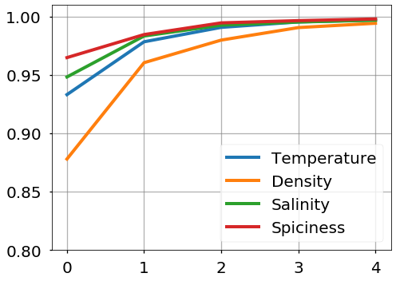

#### 2.3 - Output Log Transformation

The distribution of the outputs are skewed because there is a lot more variability in the upper depths than the lower depths. Because the distribution of the outputs are fairly skewed, we propose to do a log transformation to make them normally distributed.

```
ytrain = np.log(y)
ytest = np.log(yte)

ytrain.shape, ytest.shape
```

```
((2860, 276), (162, 276))
```

### 3 - Train,Test Split

We split the data into 80% training and 20% training.

**Note**: because the dataset we are dealing with is only ~3,000 data points, we will do some bootstrap techniques in the full experiment to see how well we do with different subsamples of data.

```
Xtrain, Xvalid, ytrain, yvalid =  train_test_split(
        Xtrain, ytrain,
        train_size=.8, random_state=1
    )
```

```
X_transformer = StandardScaler(with_mean=True, with_std=True)

# fit transform to data
X_transformer.fit(Xtrain)

# transform data
Xtrain = X_transformer.fit_transform(Xtrain)
Xvalid = X_transformer.transform(Xvalid)
Xtest = X_transformer.transform(Xtest)
```

#### 4.3 - Normalize Outputs

```
output_transformer = StandardScaler(with_mean=True, with_std=False)

ytrain = output_transformer.fit_transform(ytrain)
yvalid = output_transformer.fit_transform(yvalid)

ytest = output_transformer.transform(ytest)
```

### 5 - Train ML Model

```
from models.baseline import train_glm_model, train_gp_model, train_mlp_model, train_lr_model, train_mo_rf_model
```

#### 5.1 - Linear Regression

```
model = train_lr_model(Xtrain, ytrain)
```

```
model = train_gp_model(Xtrain, ytrain, verbose=2)
```

```
Training time: 325.695 secs.
```

#### 5.3 - (2-Layer) MultiPerceptron Model

```
model = train_mlp_model(Xtrain, ytrain, verbose=1, valid=0.1)
```

[output not shown]

[output cut: 109 more lines]

[output not shown]

#### 5.4 - Random Forest Model

```
rf_model = train_rf_model(Xtrain, ytrain, verbose=2, n_jobs=1, mo_jobs=8)
```

```
[Parallel(n_jobs=1)]: Using backend SequentialBackend with 1 concurrent workers.
```

[output not shown]

#### 5.5 - Gaussian Process

```
model = train_gp_model(Xtrain, ytrain, verbose=1)
```

```
Training time: 528.233 secs.
```

### 6 - Test ML Model

#### 6.1 - Training Data Results

This is often not reported but it is very good to check how well a model does on the initial training data because we have no entered a validation set. If we find that the training stats are too high and the testing stats are very low then we know that we're either overfitting and/or our model is not generalizing very well.

First we will look at the statistics on average to see what we get.

```
ypred = model.predict(Xtrain)
```

```
min_lim = np.min(np.concatenate((ypred, ytrain)))
max_lim = np.max(np.concatenate((ypred, ytrain)))


plt.scatter(ypred, ytrain)
plt.plot(np.linspace(min_lim, max_lim), np.linspace(min_lim, max_lim), color='black', zorder=3)
plt.xlim([min_lim, max_lim])
plt.ylim([min_lim, max_lim])
```

```
(-3.2836916337021815, 4.282232349201212)
```

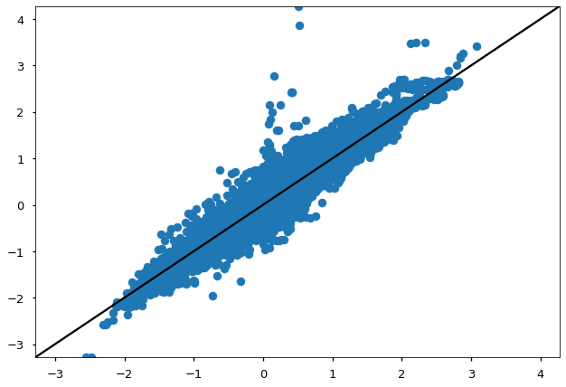

```
stat_mod = smi.OLS(ypred.ravel(), ytrain.ravel())

res = stat_mod.fit()

print(res.summary())
```

```
                                 OLS Regression Results
=======================================================================================
Dep. Variable:                      y   R-squared (uncentered):                   0.957
Model:                            OLS   Adj. R-squared (uncentered):              0.957
Method:                 Least Squares   F-statistic:                          1.416e+07
Date:                Mon, 27 Jan 2020   Prob (F-statistic):                        0.00
Time:                        12:19:53   Log-Likelihood:                      6.7167e+05
No. Observations:              631488   AIC:                                 -1.343e+06
Df Residuals:                  631487   BIC:                                 -1.343e+06
Df Model:                           1
Covariance Type:            nonrobust
==============================================================================
                 coef    std err          t      P>|t|      [0.025      0.975]
------------------------------------------------------------------------------
x1             0.9518      0.000   3762.815      0.000       0.951       0.952
==============================================================================
Omnibus:                   189835.406   Durbin-Watson:                   0.313
Prob(Omnibus):                  0.000   Jarque-Bera (JB):          9389337.239
Skew:                          -0.681   Prob(JB):                         0.00
Kurtosis:                      21.841   Cond. No.                         1.00
==============================================================================

Warnings:
[1] Standard Errors assume that the covariance matrix of the errors is correctly specified.
```

```
# each level
each_level = False

stats = get_stats(ypred, ytrain, each_level=each_level)

stats
```

|  | mae | mse | rmse | r2 |
| --- | --- | --- | --- | --- |
| 0 | 0.06107 | 0.007378 | 0.007378 | 0.951758 |

Then we can look at the statistics for each level.

```
each_level = True

stats_df = get_stats(ypred, ytrain, each_level=each_level)

stats_df.head()
```

|  | mae | mse | rmse | r2 |
| --- | --- | --- | --- | --- |
| 0 | 0.095378 | 0.017321 | 0.131608 | 0.971141 |
| 1 | 0.088260 | 0.014260 | 0.119415 | 0.976678 |
| 2 | 0.084835 | 0.012756 | 0.112944 | 0.979512 |
| 3 | 0.085067 | 0.012643 | 0.112440 | 0.979916 |
| 4 | 0.082786 | 0.011962 | 0.109371 | 0.980980 |

```
statistic = 'r2'

plt.style.use('seaborn-talk')
plot_mo_stats(stats_df, stat='r2', save_name='train_mlp')
plot_mo_stats(stats_df, stat='rmse', save_name='train_mlp')
```

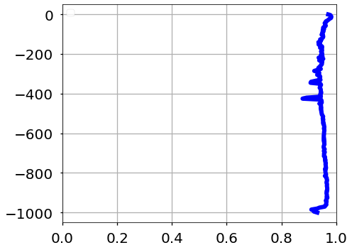

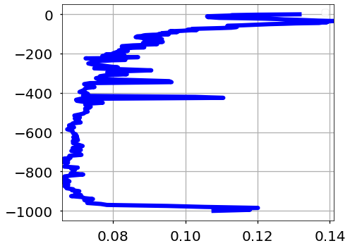

#### 6.2 - Testing Data Results

```
ypred = model.predict(Xtest)
```

```
min_lim = np.min(np.concatenate((ypred, ytest)))
max_lim = np.max(np.concatenate((ypred, ytest)))


plt.scatter(ypred, ytest)
plt.plot(np.linspace(min_lim, max_lim), np.linspace(min_lim, max_lim), color='black', zorder=3)
plt.xlim([min_lim, max_lim])
plt.ylim([min_lim, max_lim])
```

```
(-1.551942069352794, 2.87846572477131)
```

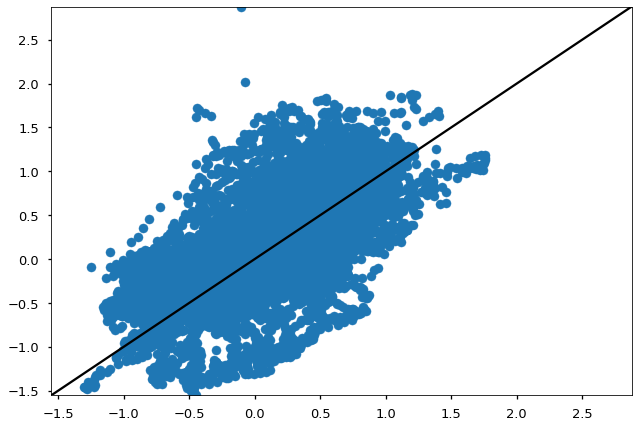

```
stat_mod = smi.OLS(ypred.ravel(), ytest.ravel())

res = stat_mod.fit()

print(res.summary())
```

```
                                 OLS Regression Results
=======================================================================================
Dep. Variable:                      y   R-squared (uncentered):                   0.331
Model:                            OLS   Adj. R-squared (uncentered):              0.331
Method:                 Least Squares   F-statistic:                          2.210e+04
Date:                Mon, 27 Jan 2020   Prob (F-statistic):                        0.00
Time:                        12:20:01   Log-Likelihood:                         -4766.7
No. Observations:               44712   AIC:                                      9535.
Df Residuals:                   44711   BIC:                                      9544.
Df Model:                           1
Covariance Type:            nonrobust
==============================================================================
                 coef    std err          t      P>|t|      [0.025      0.975]
------------------------------------------------------------------------------
x1             0.5448      0.004    148.665      0.000       0.538       0.552
==============================================================================
Omnibus:                     2050.547   Durbin-Watson:                   0.034
Prob(Omnibus):                  0.000   Jarque-Bera (JB):             5794.388
Skew:                           0.209   Prob(JB):                         0.00
Kurtosis:                       4.713   Cond. No.                         1.00
==============================================================================

Warnings:
[1] Standard Errors assume that the covariance matrix of the errors is correctly specified.
```

```
each_level = True

stats_df = get_stats(ypred, ytest, each_level=each_level)

stats_df.head()
```

|  | mae | mse | rmse | r2 |
| --- | --- | --- | --- | --- |
| 0 | 0.422045 | 0.281784 | 0.530833 | 0.490588 |
| 1 | 0.439044 | 0.299561 | 0.547322 | 0.487759 |
| 2 | 0.443207 | 0.312055 | 0.558618 | 0.490522 |
| 3 | 0.458520 | 0.327489 | 0.572267 | 0.487148 |
| 4 | 0.453541 | 0.327009 | 0.571847 | 0.496453 |

```
statistic = 'r2'
plt.style.use('seaborn-talk')
plot_mo_stats(stats_df, stat='r2', save_name='test_mlp')
plot_mo_stats(stats_df, stat='rmse', save_name='test_mlp')
```

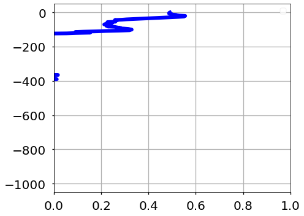

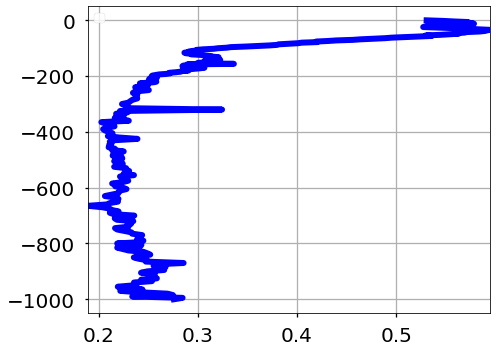

#### 6.3 - Validation Profile

```
ypred = model.predict(Xtest)
```

```
# initialize class
valid_getter = ValidationFloats('na')

# get validation floats
valid_getter.get_validation_floats('na')
```

```
[6901486, 3902123]
```

```
# get timeseries
y_validation = valid_getter.get_validation_res(ypred, ytest, 0)

y_validation.head()
```

```
(162, 2) (162, 276)
```

|  | n_cycle | Depth | Predictions | Test |
| --- | --- | --- | --- | --- |
| 0 | 3.0 | 0 | 1.005610 | 0.887168 |
| 1 | 12.0 | 0 | 0.818398 | 0.703823 |
| 2 | 24.0 | 0 | 1.029707 | 0.919995 |
| 3 | 25.0 | 0 | 1.062241 | 1.697790 |
| 4 | 26.0 | 0 | 1.066075 | 1.673884 |

```
model_name = 'mlp'
ifloat = 6901486
```

[output not shown]

[figure not shown]

[output not shown]

[figure not shown]

```
stat_mod = smi.OLS(y_validation['Predictions'], y_validation['Test'].ravel())

res = stat_mod.fit()

print(res.summary())
```

```
                                 OLS Regression Results
=======================================================================================
Dep. Variable:            Predictions   R-squared (uncentered):                   0.314
Model:                            OLS   Adj. R-squared (uncentered):              0.314
Method:                 Least Squares   F-statistic:                          1.689e+04
Date:                Mon, 27 Jan 2020   Prob (F-statistic):                        0.00
Time:                        12:20:15   Log-Likelihood:                         -8176.4
No. Observations:               36984   AIC:                                  1.635e+04
Df Residuals:                   36983   BIC:                                  1.636e+04
Df Model:                           1
Covariance Type:            nonrobust
==============================================================================
                 coef    std err          t      P>|t|      [0.025      0.975]
------------------------------------------------------------------------------
x1             0.6573      0.005    129.966      0.000       0.647       0.667
==============================================================================
Omnibus:                     5008.458   Durbin-Watson:                   0.619
Prob(Omnibus):                  0.000   Jarque-Bera (JB):            26607.874
Skew:                           0.547   Prob(JB):                         0.00
Kurtosis:                       7.009   Cond. No.                         1.00
==============================================================================

Warnings:
[1] Standard Errors assume that the covariance matrix of the errors is correctly specified.
```

```
# each level
each_level = False

stats = get_stats(ypred, ytest, each_level=each_level)

stats
```

|  | mae | mse | rmse | r2 |
| --- | --- | --- | --- | --- |
| 0 | 0.239304 | 0.102378 | 0.102378 | -1.27019 |

```
each_level = True

stats_df = get_stats(ypred, ytest, each_level=each_level)

stats_df.head()
```

|  | mae | mse | rmse | r2 |
| --- | --- | --- | --- | --- |
| 0 | 0.406305 | 0.267202 | 0.516915 | 0.516951 |
| 1 | 0.426680 | 0.294181 | 0.542385 | 0.496959 |
| 2 | 0.431409 | 0.302646 | 0.550133 | 0.505883 |
| 3 | 0.447864 | 0.317618 | 0.563576 | 0.502607 |
| 4 | 0.448236 | 0.322170 | 0.567600 | 0.503906 |

```
statistic = 'r2'
plt.style.use('seaborn-talk')
plot_mo_stats(stats_df, stat='r2', save_name='valid_mlp')
plot_mo_stats(stats_df, stat='rmse', save_name='valid_mlp')
```

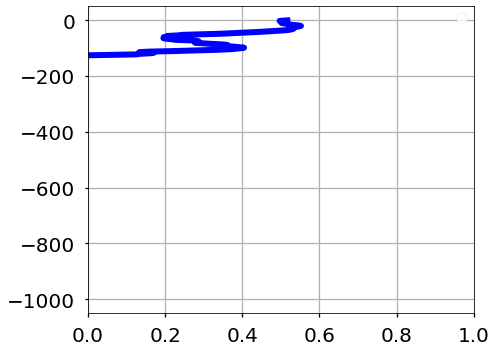

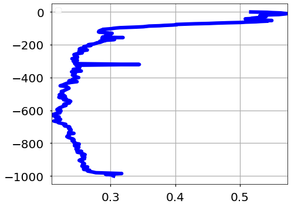

### 7 - Post Analysis

#### 7.1 - Feature Importance

For some algorithms, we can calculate the feature importance based on the inputs dimensions. This is true for the random forest model.

[output not shown]

```
{'bootstrap': True,
 'ccp_alpha': 0.0,
 'criterion': 'mse',
 'max_depth': None,
 'max_features': 'auto',
 'max_leaf_nodes': None,
 'max_samples': None,
 'min_impurity_decrease': 0.0,
 'min_impurity_split': None,
 'min_samples_leaf': 1,
 'min_samples_split': 2,
 'min_weight_fraction_leaf': 0.0,
 'n_estimators': 1500,
 'n_jobs': -1,
 'oob_score': False,
 'random_state': 123,
 'verbose': 0,
 'warm_start': False}
```

```
tree_feature_importances = \
    rf_model.feature_importances_

feature_names = np.asarray(new_columns) #np.concatenate((core_columns.values, np.array(pca_columns)))

assert feature_names.shape[0] == tree_feature_importances.shape[0], "Shapes don't match"

sorted_idx = tree_feature_importances.argsort()
```

```
SAVE_PATH = "/media/disk/erc/papers/2019_ML_OCN/ml4ocean/reports/figures/"
save_name = 'na'
y_ticks = np.arange(0, len(feature_names))
plt.style.use(['seaborn-talk'])
fig, ax = plt.subplots(figsize=(10,10))
ax.barh(y_ticks, tree_feature_importances[sorted_idx], zorder=3, height=0.8)
ax.set_yticklabels(feature_names[sorted_idx])
ax.set_yticks(y_ticks)
# ax.set_title("Random Forest Feature Importances (MDI)")
ax.tick_params(axis="both", which="major", labelsize=20)
ax.tick_params(axis="both", which="minor", labelsize=20)
ax.grid(alpha=0.6, color='gray', zorder=0)
plt.tight_layout()
plt.show()
# fig.savefig(SAVE_PATH + f"fi_{save_name}.png")
```

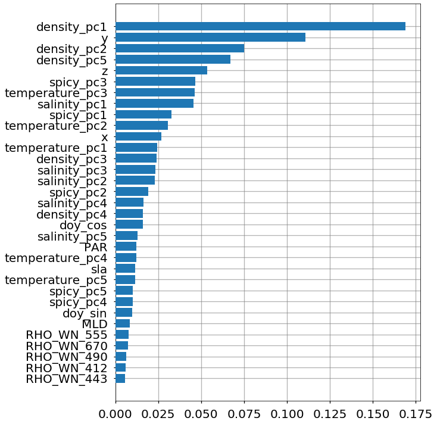

#### 7.2 - Permutation Plot

```
perm_result_test = permutation_importance(
    rf_model,
    Xtest,
    ytest,
    n_repeats=10,
    random_state=42,
    n_jobs=1
)
```

[output not shown]

[output cut: 2262 more lines]

[output not shown]

```
sorted_idx = perm_result_test.importances_mean.argsort()
```

```
fig, ax = plt.subplots(figsize=(10,10))
plt.style.use(['seaborn-talk'])
ax.boxplot(
    perm_result_test.importances[sorted_idx].T,
    vert=False,
    labels=feature_names[sorted_idx]
)
ax.set_title("Permutation Importances (Test set)")
fig.tight_layout()
plt.show()
```

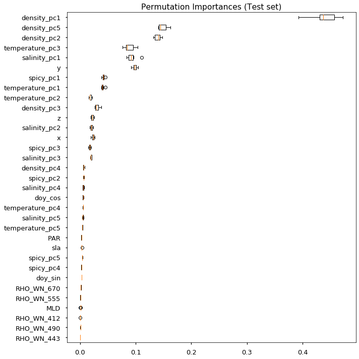

```
perm_result_train = permutation_importance(
    rf_model,
    Xtrain,
    ytrain,
    n_repeats=10,
    random_state=42,
    n_jobs=1
)
```

[output not shown]

[output cut: 1258 more lines]

[output not shown]

[output not shown]

[output cut: 80 more lines]

[output not shown]

```
sorted_idx = perm_result_train.importances_mean.argsort()
```

[output not shown]

## Subtropical Gyros

#### Load Data

```
X_core = load_standard_data('STG', training=True)

# Testing Data
X_core_te = load_standard_data('STG', training=False)


X_core_te = X_core_te.iloc[:, 2:]

X_core.shape, X_core_te.shape
```

```
((1353, 11), (133, 11))
```

```
X_temp, X_dens, X_sal, X_spicy = load_high_dim_data('STG', training=True)

# add prefix (Training/Validation)
X_temp = X_temp.add_prefix('temp_')
X_dens = X_dens.add_prefix('dens_')
X_sal = X_sal.add_prefix('sal_')
X_spicy = X_spicy.add_prefix('spice_')

#
X_temp_te, X_dens_te, X_sal_te, X_spicy_te = load_high_dim_data('STG', training=False)


# Subset
X_temp_te = X_temp_te.iloc[:, 2:]
X_dens_te = X_dens_te.iloc[:, 2:]
X_sal_te= X_sal_te.iloc[:, 2:]
X_spicy_te = X_spicy_te.iloc[:, 2:]

# add prefix (Test)
X_temp_te = X_temp_te.add_prefix('temp_')
X_dens_te = X_dens_te.add_prefix('dens_')
X_sal_te = X_sal_te.add_prefix('sal_')
X_spicy_te = X_spicy_te.add_prefix('spice_')
```

```
y = load_labels('STG', training=True)

yte = load_labels('STG', training=False)

yte = yte.iloc[:, 2:]
```

```
# Training Data
Xtr = pd.concat([
    X_core,
    X_temp,
    X_dens,
    X_sal,
    X_spicy
], axis=1)



# Testing Data
Xte = pd.concat([
    X_core_te,
    X_temp_te,
    X_dens_te,
    X_sal_te,
    X_spicy_te
], axis=1)
```

#### Tre Transformations

```
# new columns columns
temp_columns = X_temp.columns.values
dens_columns = X_dens.columns.values
sal_columns = X_sal.columns.values
spicy_columns = X_spicy.columns.values
core_columns = ['sla', "PAR","RHO_WN_412","RHO_WN_443","RHO_WN_490","RHO_WN_555","RHO_WN_670","MLD"]
time_columns = ['doy']
loc_columns = ['lat', 'lon']

n_components = 5
times = ['doy']

new_columns = [
    *["doy_cos", "doy_sin"],
    *['x', 'y', 'z',],
    *[f"temperature_pc{icomponent+1}" for icomponent in range(n_components)],
    *[f"density_pc{icomponent+1}" for icomponent in range(n_components)],
    *[f"salinity_pc{icomponent+1}" for icomponent in range(n_components)],
    *[f"spicy_pc{icomponent+1}" for icomponent in range(n_components)],
    *core_columns,
]
seed = 123
# define transfomer
X_transformer = ColumnTransformer(
    [   ("time", CycleTransform(times), time_columns),
        ("space", GeoCartTransform(), loc_columns),
        ('temp', PCA(n_components=n_components, random_state=seed), temp_columns),
        ('dens', PCA(n_components=n_components, random_state=seed), dens_columns),
        ('sal', PCA(n_components=n_components, random_state=seed), sal_columns),
        ('spice', PCA(n_components=n_components, random_state=seed), spicy_columns),
#         ('core', StandardScaler(with_mean=True, with_std=True), core_columns)
    ],
    remainder='passthrough'
)
# fit transform to data
X_transformer.fit(Xtr)

# transform data
Xtrain = X_transformer.fit_transform(Xtr)
Xtest = X_transformer.transform(Xte)
```

```
ytrain = np.log(y)
ytest = np.log(yte)

ytrain.shape, ytest.shape
```

```
((1353, 276), (133, 276))
```

#### Train-Test Split

```
Xtrain, Xvalid, ytrain, yvalid =  train_test_split(
        Xtrain, ytrain,
        train_size=.8, random_state=1
    )
```

#### Post Transformations

```
X_transformer = StandardScaler(with_mean=True, with_std=True)

# fit transform to data
X_transformer.fit(Xtrain)

# transform data
Xtrain = X_transformer.fit_transform(Xtrain)
Xvalid = X_transformer.transform(Xvalid)
Xtest = X_transformer.transform(Xtest)
```

```
output_transformer = StandardScaler(with_mean=True, with_std=False)

ytrain = output_transformer.fit_transform(ytrain)
yvalid = output_transformer.fit_transform(yvalid)
ytest = output_transformer.transform(ytest)
```

#### Train ML Model

```
model = train_mlp_model(Xtrain, ytrain, verbose=1, valid=0.1)
```

[output not shown]

[output cut: 168 more lines]

[output not shown]

#### Test ML Model

```
ypred = model.predict(Xtest)
# each level
each_level = False

stats = get_stats(ypred, ytest, each_level=each_level)

stats
```

|  | mae | mse | rmse | r2 |
| --- | --- | --- | --- | --- |
| 0 | 0.076336 | 0.011636 | 0.011636 | 0.812559 |

```
each_level = True

stats_df = get_stats(ypred, ytest, each_level=each_level)

stats_df.head()
```

|  | mae | mse | rmse | r2 |
| --- | --- | --- | --- | --- |
| 0 | 0.088556 | 0.020310 | 0.142513 | 0.717452 |
| 1 | 0.081911 | 0.015445 | 0.124277 | 0.762677 |
| 2 | 0.076586 | 0.011129 | 0.105496 | 0.814074 |
| 3 | 0.081023 | 0.013181 | 0.114808 | 0.789395 |
| 4 | 0.073182 | 0.009919 | 0.099596 | 0.820807 |

```
statistic = 'r2'
plt.style.use('seaborn-talk')
plot_mo_stats(
    stats_df,
    stat='r2',
    save_name='stg_test',
    color='red'
)
```

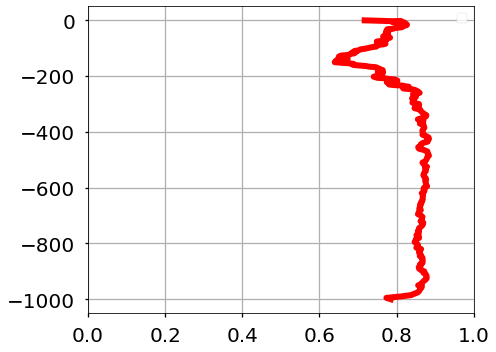

```
plot_mo_stats(stats_df, stat='mae', save_name='stg_test', color='red')
plot_mo_stats(stats_df, stat='mse', save_name='stg_test', color='red')
plot_mo_stats(stats_df, stat='rmse', save_name='stg_test', color='red')
```

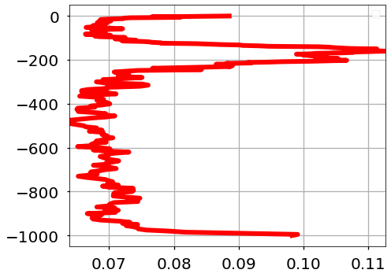

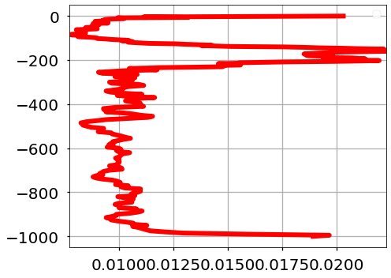

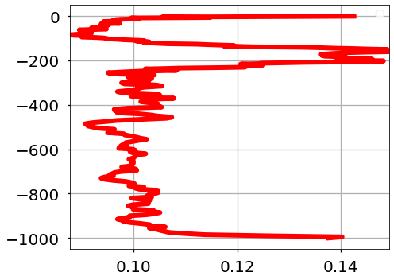

#### Post Analysis

```
tree_feature_importances = \
    rf_model.feature_importances_

feature_names = np.asarray(new_columns) #np.concatenate((core_columns.values, np.array(pca_columns)))

assert feature_names.shape[0] == tree_feature_importances.shape[0], "Shapes don't match"

sorted_idx = tree_feature_importances.argsort()
```

```
SAVE_PATH = "/media/disk/erc/papers/2019_ML_OCN/ml4ocean/reports/figures/"
save_name = 'stg'
y_ticks = np.arange(0, len(feature_names))
plt.style.use(['seaborn-talk'])
fig, ax = plt.subplots(figsize=(10,10))
ax.barh(y_ticks, tree_feature_importances[sorted_idx], zorder=3, height=0.8, color='red')
ax.set_yticklabels(feature_names[sorted_idx])
ax.set_yticks(y_ticks)
# ax.set_title("Random Forest Feature Importances (MDI)")
ax.tick_params(axis="both", which="major", labelsize=20)
ax.tick_params(axis="both", which="minor", labelsize=20)
ax.grid(alpha=0.6, color='gray', zorder=0)
plt.tight_layout()
plt.show()
fig.savefig(SAVE_PATH + f"fi_{save_name}.png")
```

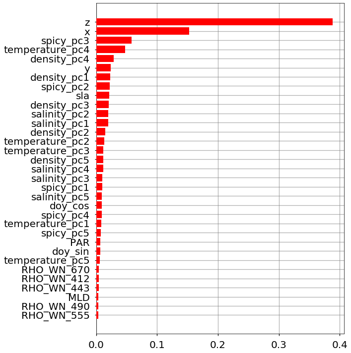

```
depths = 276
first = [*range(1, 250)]
d1 = first[::2]

second = [*range(251,1000)]
d2 = second[::5]
```

```
len(d1), len(d2)
```

```
(125, 150)
```

```
plt.plot(-np.concatenate((d1,d2)))
```

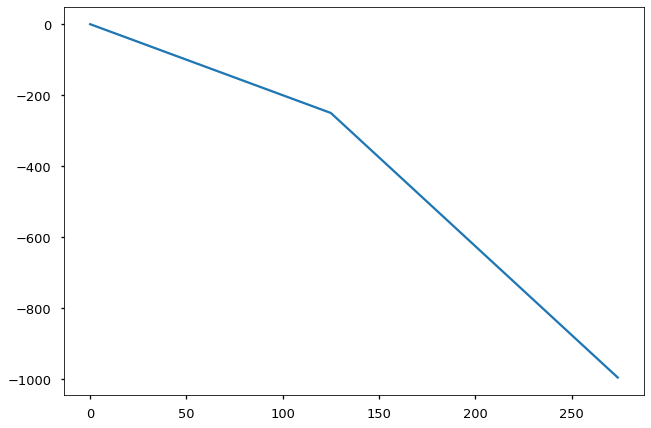